# Digitala perspektiv på varumärken

## Hyper-Personalized Brand Communication

- Predictive analytics helps brands anticipate customer needs and offer relevant content.
- Personalization enhances customer engagement, retention, and brand loyalty.
- AI-driven hyper-personalization uses real-time data to create dynamic, adaptive communication.
- Ethical considerations arise around privacy and data protection in hyper-personalized marketing.

[figure not shown]

## Generative AI

- Generative AI creates new content, such as text, images, and videos, based on learned patterns.
- It uses deep learning models like GANs (Generative Adversarial Networks) and transformers.
- Businesses leverage generative AI for automated design, content creation, and product development.
- AI-generated content can enhance creativity but raises ethical concerns around authenticity.

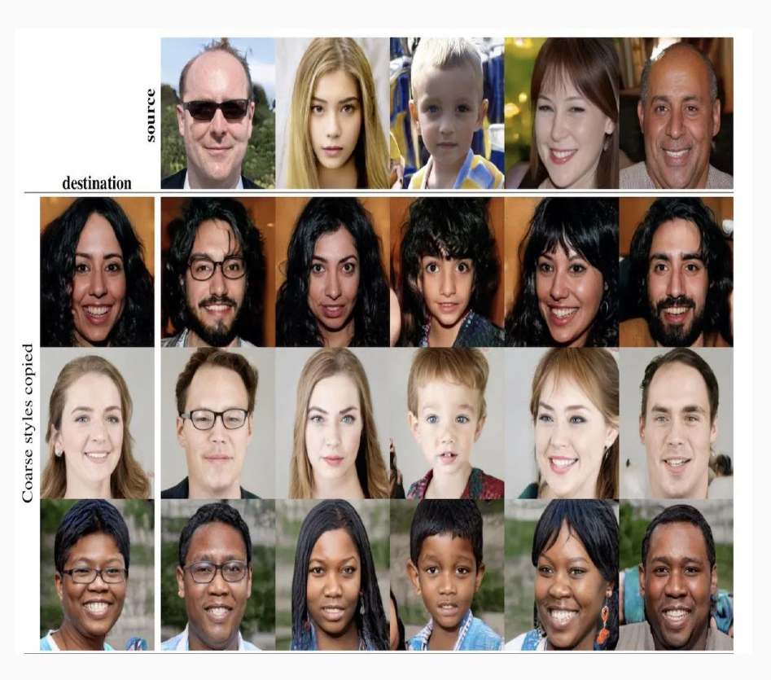

## AI and Corporate Chatbots

- Corporate chatbots streamline customer service by providing instant, automated responses.
- AI-powered bots improve efficiency by handling FAQs, troubleshooting, and transaction support.
- Brands use chatbots to engage customers 24/7, reducing response times and operational costs.
- Human oversight is essential to ensure chatbots maintain proper tone and handle complex inquiries.

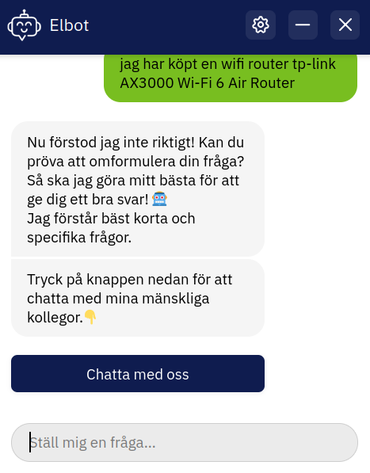

## AI-Generated Brand Communication

- AI automates brand messaging, ensuring consistency and efficiency across multiple channels.
- Natural language processing (NLP) enables AI to craft personalized and context-aware communication.
- AI-driven communication helps brands scale their engagement without increasing human effort.
- AI must align with brand voice and values to maintain authenticity and trustworthiness.

[figure not shown]

## AI and Brand Avatars

- AI brand avatars are digital representations of a brand, interacting with customers in real-time.
- These avatars can be animated or AI-driven personalities, enhancing brand storytelling.
- Virtual influencers and AI-generated brand ambassadors are reshaping digital marketing.
- AI avatars can provide consistent brand messaging across social media, websites, and virtual spaces.

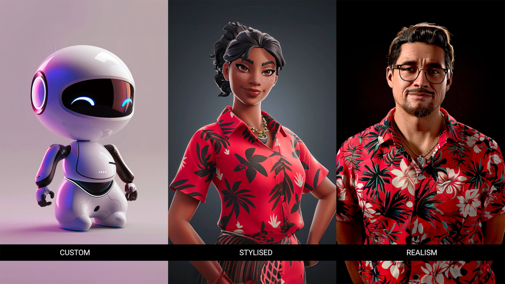

## Brand Communication and AI

- **Hyper-Personalization** – Predictive AI refines brand messaging by analyzing consumer data, enhancing targeted communication.
- **AI-Generated Content** – Generative AI disrupts traditional branding by autonomously creating ads, visuals, and even product designs.
- **Erosion of Brand Authenticity** – AI-driven branding risks losing human creativity and emotional connection, making brands feel less personal.
- **Symbolic Branding at Scale** – AI enables brands to craft personalized symbols and narratives, adapting them dynamically for different audiences.
- **Challenges to Brand Control** – Consumers and AI tools can now co-create and modify brand meanings, shifting authority away from companies.

## References

Chicotsky, Brandon. 2023. “Web3 and Marketing: The New Frontier.” Article. *Applied Marketing Analytics* 9 (2): 182–94. https://doi.org/10.69554/eygn7624.

Darwish, Dina. 2024. *Web 3: Definition, Technologies, and Tools*. Book chapter. *Decentralizing the Online Experience With Web3 Technologies*. https://doi.org/10.4018/979-8-3693-1532-3.ch001.

Du, Mingxiao, Xiaofeng Ma, Zhe Zhang, Xiangwei Wang, and Qijun Chen. 2017. “A Review on Consensus Algorithm of Blockchain.” Conference paper. *2017 IEEE International Conference on Systems, Man, and Cybernetics, SMC 2017*. https://doi.org/10.1109/SMC.2017.8123011.

Elliott, Richard H, Richard Rosenbaum-Elliott, Larry Percy, and Simon Pervan. 2015. *Strategic Brand Management*. Oxford University Press, USA.

Fuchs, Christian, Wolfgang Hofkirchner, Matthias Schafranek, Celina Raffl, Marisol Sandoval, and Robert Bichler. 2010. “Theoretical Foundations of the Web: Cognition, Communication, and Co-Operation. Towards an Understanding of Web 1.0, 2.0, 3.0.” Article. *Future Internet* 2 (1): 41–59. https://doi.org/10.3390/fi2010041.

Garrigos-Simon, Fernando J., Rafael Lapiedra Alcamí, and Teresa Barberá Ribera. 2012. “Social Networks and Web 3.0: Their Impact on the Management and Marketing of Organizations.” Article. *Management Decision* 50 (10): 1880–90. https://doi.org/10.1108/00251741211279657.

Gasser, Linus. 2023. *WEB3*. Book chapter. *Trends in Data Protection and Encryption Technologies*. https://doi.org/10.1007/978-3-031-33386-6_34.

Holt, Douglas B. 2004. “How Brands Become Icons: The Principles of Cultural Branding.” *Harvard Business Review Press*.

Kukreja, Dhaval, Shikha Gupta, Dheeraj Patel, and J. N. Rai. 2023. “Scientometric Review of Web 3.0.” Article. *Journal of Information Science*. https://doi.org/10.1177/01655515231182073.

Lassila, Ora, and James Hendler. 2007. “Embracing "Web 3.0".” Article. *IEEE Internet Computing* 11 (3): 90–93. https://doi.org/10.1109/MIC.2007.52.

Lekhi, Pooja, and Guneet Kaur. 2023. *Concepts, Technologies, Challenges, and the Future of Web 3*. Book. *Concepts, Technologies, Challenges, and the Future of Web 3*. https://doi.org/10.4018/978-1-6684-9919-1.

Megala, R., M. Janani, S. Rithika, S. K. Shrinaya, and S. Swetha. 2023. “Web 3.0: A Decentralized Future Empowered by Blockchain.” Conference paper. *Proceedings - 3rd International Conference on Smart Technologies, Communication and Robotics 2023, STCR 2023*. https://doi.org/10.1109/STCR59085.2023.10397036.

Miller, Irina S., Irina A. Gereikhanova, Anna S. Konstantinova, Lubov N. Pereyashkina, and Anastasia N. Udotova. 2024. “Transforming Communication Flows Between Organizations and Their Publics in the Context of Emerging Web 3.0.” Book chapter. *Advances in Science, Technology and Innovation* Part F2356: 191–95. https://doi.org/10.1007/978-3-031-49711-7_33.

Murugaraj, Pon Rahul. 2023. “Web 3.0: Are We Building a True Consensual Internet or yet Another Strategic Platform?” Conference paper. *International Conference on Information Systems, ICIS 2023: "Rising Like a Phoenix: Emerging from the Pandemic and Reshaping Human Endeavors with Digital Technologies"*. https://www.scopus.com/inward/record.uri?eid=2-s2.0-85192536652&partnerID=40&md5=16b1a5d2e917e4f102442bf3874ce0e0.

Östberg, Jacob, and Anders Bengtsson. 2018. *Märken Och människor: Om Marknadssymboler Som Kulturella Resurser*. Studentlitteratur.

Shilina, Sasha. 2023. *The Promise of Blockchain-Based Decentralized Social Networks: Enabling Privacy, Censorship Resistance, and User Control*. Book chapter. *Concepts, Technologies, Challenges, and the Future of Web 3*. https://doi.org/10.4018/978-1-6684-9919-1.ch010.

Sisodia, Himanshu. 2023. *Decentralized Identity in Web 3: Transforming Marketing and Consumer Engagement*. Book chapter. *Concepts, Technologies, Challenges, and the Future of Web 3*. https://doi.org/10.4018/978-1-6684-9919-1.ch020.

Tagg, Stephen, Alan Stevenson, and Tiziano Vescovi. 2013. *New Developments in Online Marketing*. Book. *New Developments in Online Marketing*. https://doi.org/10.4324/9780203722381.

Vayadande, Kuldeep, Abhilash Baviskar, Jaywant Avhad, Susmit Bahadkar, Parth Bhalerao, and Akash Chimkar. 2024. “A Comprehensive Review on Navigating the Web 3.0 Landscape.” Conference paper. *Proceedings - 2024 2nd International Conference on Inventive Computing and Informatics, ICICI 2024*. https://doi.org/10.1109/ICICI62254.2024.00080.

Wan, Shicheng, Hong Lin, Wensheng Gan, Jiahui Chen, and Philip S. Yu. 2024. “Web3: The Next Internet Revolution.” Article. *IEEE Internet of Things Journal* 11 (21): 34811–25. https://doi.org/10.1109/JIOT.2024.3432116.